# Third Week: Exploratory Data Analysis

LaLiga Analysis

Aryan Tajmirriahi

2018-02-27 03:00:18

# تمرین سری سوم: از لالیگا تا لیگ برتر

> با استفاده از داده های لیگ دسته اول اسپانیا به سوالات زیر پاسخ دهید. از هر دو ابزار ggplot2 و highcharter برای این کار تصویرسازی استفاده نمایید.

در کلیه سوالات فرض شده معیار قهرمانی ابتدا امتیاز سپس تفاضل گل و سپس گل زده است. برای کار کرد درست کد ها ابتدا قطعه کد زیر را اجرا کنید:

```r
library(engsoccerdata)
library(dplyr)
```

```r
library(highcharter)
library(ggplot2)
library(ggthemes)
spn = as.tbl(spain)
rbind(spn %>% select(Season, tier, Date, team = home, opp = visitor, GF = hgoal, GA = vgoal),
      spn %>% select(Season, tier, Date, team = visitor, opp = home, GF = vgoal, GA = hgoal)
) %>% mutate(GD = GF - GA, point = 3* (GD > 0) + (GD == 0)) %>% group_by(Season, tier, team) %>% mutate(week_no = row_number(Date), rem_week = n() - week_no) %>% arrange(week_no) %>% mutate(cum_score = cumsum(point), cum_GD = cumsum(GD), cum_GF = cumsum(GF), cum_GA = cumsum(GA), Win = cumsum(GD > 0), Draw = cumsum(GD == 0), Lose = cumsum(GD < 0)) %>% group_by(Season, tier, week_no) %>% mutate(rank = n() + 1 - rank(order(order(cum_score, cum_GD)), ties.method = 'first')) -> full_info

full_info %>% group_by(Season, tier, team) %>% arrange(desc(week_no)) %>% slice(1) -> finals

finals %>% group_by(Season, tier) %>% arrange(rank) %>% slice(1) %>% filter(tier == 1) %>%  select(team, Season, score = cum_score) -> champ
champ %>% group_by(team) %>% summarise(num = n()) %>% arrange(desc(num)) -> num_champ
#View(num_champ)

full_info %>% filter(week_no == rem_week) %>% group_by(Season, tier) %>% arrange(rank) %>% slice(1) %>% filter(tier == 1) %>%  select(team, Season, score = cum_score) -> half_champ
```

۱. تعداد قهرمانی های تیم ها در تاریخ لالیگا را استخراج کرده و نمودار ستونی آنها را رسم کنید.

```r
num_champ %>% hchart(type = "bar", hcaes(x = team, y = num)) %>% hc_add_theme(hc_theme_darkunica())
```

[interactive chart not shown]

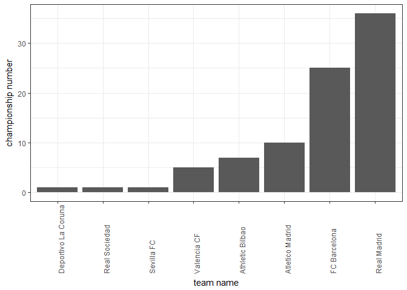

```r
p = ggplot(data = num_champ, aes(x = reorder(team, num), y = num))
print(p + geom_col() + theme_bw() + theme(axis.text.x = element_text(angle = 90, hjust = 0)) + xlab("team name") + ylab("championship number"))
```

۲. کسل کننده ترین لیگ و تیم را بیابید. نمودار ده تیم و ده فصل کسل کننده را رسم کنید.

```r
finals %>% group_by(team) %>% summarise(tot_G = (sum(cum_GA) + sum(cum_GF)) / sum(week_no)) %>% arrange(tot_G)%>% slice(1:10) -> stat
stat %>% hchart(type = "bar", hcaes(x = team, y = tot_G))
```

[interactive chart not shown]

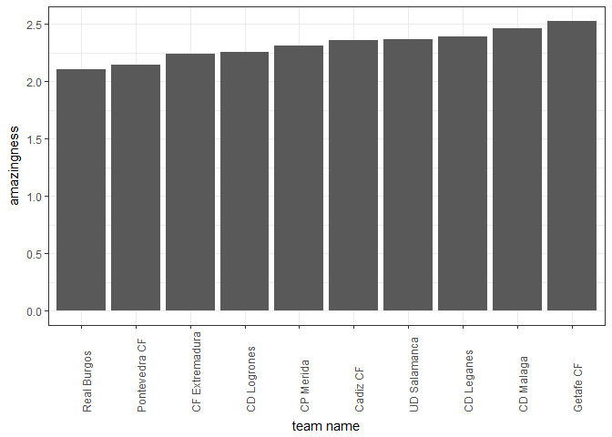

```r
ggplot(data = stat, aes(x = reorder(team, tot_G), y = tot_G)) + geom_col() + theme_bw() + theme(axis.text.x = element_text(angle = 90, hjust = 0)) + xlab("team name") + ylab("amazingness")
```

```r
finals %>% group_by(Season) %>% summarise(num_D = 2 * sum(Draw) / sum(week_no)) %>% arrange(desc(num_D)) %>% slice(1:10) -> stat
stat %>% hchart(type = "column", hcaes(x = as.character(Season), y = num_D))
```

[interactive chart not shown]

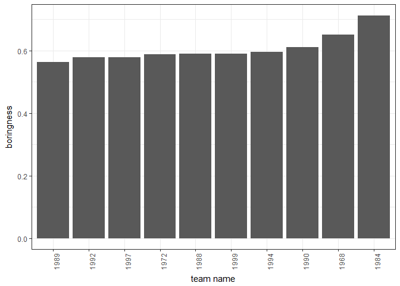

```r
ggplot(data = stat, aes(x = reorder(as.character(Season), num_D), y = num_D)) + geom_col() + theme_bw() + theme(axis.text.x = element_text(angle = 90, hjust = 0)) + xlab("team name") + ylab("boringness")
```

۳. در چند درصد موارد قهرمان نیم فصل در پایان فصل قهرمان شده است؟

```r
half_champ %>% select(Season, team1 = team) -> nim
champ %>% select(Season, team) %>% full_join(nim) %>% group_by(tier) -> stat
print(sum(stat$team == stat$team1) / count(stat))
```

```
##   tier         n
## 1   45 0.5232558
```

۴. در بین سال های ۲۰۰۱ تا ۲۰۱۰ گربه سیاه تیم های بزرگ چه تیم هایی بوده است؟

برای این سوال ابتدا چند تیم قوی را انتخاب کرده و سپس از بین تیم های ضعیف آن تیم هایی را انتخاب می کنیم که این تیم ها را زیاد برده اند.

```r
full_info %>%  filter(Season >= 2001 & Season <= 2010) -> full_info_01_10
full_info_01_10 %>% filter(rem_week == 0) %>% group_by(team) %>% summarise(total_score = sum(cum_score)) %>% arrange(desc(total_score)) -> total
total %>% slice(1:4) %>% select(team) -> big_team
total %>% arrange(total_score) %>% slice(1:10) -> weak_team
big_team
```

```
## # A tibble: 4 x 1
##   team
##   <chr>
## 1 Real Madrid
## 2 FC Barcelona
## 3 Valencia CF
## 4 Sevilla FC
```

```r
weak_team
```

```
## # A tibble: 10 x 2
##    team           total_score
##    <chr>                <dbl>
##  1 Gimnastic             28.0
##  2 Xerez CD              34.0
##  3 Hercules CF           35.0
##  4 Cadiz CF              36.0
##  5 UD Las Palmas         40.0
##  6 Real Murcia           56.0
##  7 CD Numancia           64.0
##  8 CD Tenerife           74.0
##  9 Albacete              75.0
## 10 Rayo Vallecano        81.0
```

```r
full_info_01_10 %>% filter(is.element(team, weak_team$team) & is.element(opp, big_team$team)) %>% group_by(team) %>% summarise(per_win = sum(GD > 0 ) / n()) %>% arrange(desc(per_win))
```

```
## # A tibble: 10 x 2
##    team           per_win
##    <chr>            <dbl>
##  1 Hercules CF     0.250
##  2 Rayo Vallecano  0.250
##  3 UD Las Palmas   0.250
##  4 CD Numancia     0.188
##  5 Gimnastic       0.125
##  6 Real Murcia     0.125
##  7 Albacete        0.0625
##  8 Cadiz CF        0
##  9 CD Tenerife     0
## 10 Xerez CD        0
```

۵. در تاریخ لالیگا کدام تیم رکورددار زودترین قهرمانی است؟ همچنین کدام تیم مقتدرانه ترین قهرمانی را داشته است؟

```r
full_info  %>%  group_by(rank) %>% filter(rank == 1 || rank == 2) %>% group_by(Season, tier, rem_week) %>% arrange(rank) %>% summarise(t1 = max(cum_score) - min(cum_score)) %>% ungroup() %>% filter(t1 > 3 * rem_week) %>% arrange(desc(rem_week))
```

```
## # A tibble: 185 x 4
##    Season  tier rem_week    t1
##     <dbl> <dbl>    <int> <dbl>
##  1   1960  1.00        5  21.0
##  2   1962  1.00        5  17.0
##  3   1973  1.00        5  16.0
##  4   1974  1.00        5  16.0
##  5   1990  1.00        5  17.0
##  6   1960  1.00        4  19.0
##  7   1962  1.00        4  14.0
##  8   1973  1.00        4  14.0
##  9   1974  1.00        4  13.0
## 10   1984  1.00        4  13.0
## # ... with 175 more rows
```

```r
finals
```

```
## # A tibble: 1,462 x 19
## # Groups:   Season, tier, team [1,462]
##    Season  tier Date       team    opp        GF    GA    GD point week_no
##     <dbl> <dbl> <date>     <chr>   <chr>   <int> <int> <int> <dbl>   <int>
##  1   1928  1.00 1929-06-30 Arenas~ FC Bar~     0     2    -2  0         18
##  2   1928  1.00 1929-06-23 Athlet~ Real M~     2     0     2  3.00      18
##  3   1928  1.00 1929-06-23 Atleti~ Espany~     7     1     6  3.00      18
##  4   1928  1.00 1929-06-23 CE Eur~ Real S~     4     5    -1  0         18
##  5   1928  1.00 1929-06-23 Espany~ Atleti~     1     7    -6  0         18
##  6   1928  1.00 1929-06-30 FC Bar~ Arenas~     2     0     2  3.00      18
##  7   1928  1.00 1929-06-23 Racing~ Arenas~     5     1     4  3.00      18
##  8   1928  1.00 1929-06-23 Real M~ Athlet~     0     2    -2  0         18
##  9   1928  1.00 1929-06-23 Real S~ CE Eur~     5     4     1  3.00      18
## 10   1928  1.00 1929-06-23 Real U~ FC Bar~     1     4    -3  0         18
## # ... with 1,452 more rows, and 9 more variables: rem_week <int>,
## #   cum_score <dbl>, cum_GD <int>, cum_GF <int>, cum_GA <int>, Win <int>,
## #   Draw <int>, Lose <int>, rank <dbl>
```

```r
finals %>% group_by(rank) %>% filter(rank == 1 || rank == 2) %>% group_by(Season, tier) %>% summarise(diff_score = max(cum_score) - min(cum_score)) %>% ungroup() %>% arrange(desc(diff_score)) %>% slice(1)
```

```
## # A tibble: 1 x 3
##   Season  tier diff_score
##    <dbl> <dbl>      <dbl>
## 1   1962  1.00       21.0
```

۶. طولانی ترین نوار پیروزی مساوی و شکست مال چه تیم هایی است؟

برای این سوال در ابتدا در هر فصصل جستجو کردیم سپس در کل

```r
#max_s <- 0
#shaak_team <- NA
#full_info %>% ungroup() %>% mutate(is_ok = (GD > 0)) %>% arrange(Date) %>% select(Season, team, week_no, is_ok) %>% group_by(Season, team) %>% arrange(week_no) -> full_info_6
#full_info_6$Season %>% unique() -> seasons
#for(season in seasons){
#  print(season)
#  full_info_6 %>% filter(Season == season) %>% .$team %>% unique() -> teams
#  for(tteam in teams){
#    print(tteam)
#    curr_s <- 0
#    m = max(full_info_6 %>% filter(Season == season & team == tteam) %>% .$week_no)
#    xx = full_info_6 %>% filter(Season == season & team == tteam)
#    for(i in 1:m){
      #print(i)
#      xx %>% filter(week_no == i) -> x
      #print(x)
#      if(x[1,]$is_ok){
#        curr_s <- curr_s + 1
#      }else{
#        curr_s <- 0
#      }
#      if(curr_s > max_s){
#        max_s <- curr_s
#        shaak_team = tteam
#      }
#    }
#  }
#}
#print(shaak_team + " has " + as.character(max_s) + " victories")
#View(full_info_6)
#first approach


max_s <- 0
shaak_team <- NA
full_info %>% ungroup() %>% mutate(is_ok = (GD > 0)) %>% arrange(Date) %>% select(team, Date, is_ok) -> full_info_6
#full_info_6 %>% View()
#full_info_6 %>% filter(team == "Arenas de Getxo") %>% .$is_ok
teams <- full_info_6$team %>% unique()
for(tteam in teams){
  #print(max_s)
  #print(tteam)
  #print(max_s)
  curr_s <- 0
  xx = full_info_6 %>% filter(team == tteam) %>% .$is_ok
  #if(tteam == "FC Barcelona"){
  #  print(xx)
  #}
  j <- 1
  while(j <= length(xx)){
    i <- xx[j]
    #print(i)
    #print(i)
    #xx %>% filter(week_no == i) -> x
    #print(x)
    if(i){
      curr_s <- curr_s + 1
    }else{
      curr_s <- 0
    }
    if(curr_s > max_s){
      max_s <- curr_s
      shaak_team = tteam
    }
    j <- j + 1
  }
  #print(max_s)
}
print(paste(shaak_team, " has ", as.character(max_s),  " victories."))
```

```
## [1] "Real Madrid  has  16  victories."
```

```r
max_s <- 0
shaak_team <- NA
full_info %>% ungroup() %>% mutate(is_ok = (GD == 0)) %>% arrange(Date) %>% select(team, Date, is_ok) -> full_info_6
#full_info_6 %>% View()
#full_info_6 %>% filter(team == "Arenas de Getxo") %>% .$is_ok
teams <- full_info_6$team %>% unique()
for(tteam in teams){
  #print(max_s)
  #print(tteam)
  #print(max_s)
  curr_s <- 0
  xx = full_info_6 %>% filter(team == tteam) %>% .$is_ok
  #if(tteam == "FC Barcelona"){
  #  print(xx)
  #}
  j <- 1
  while(j <= length(xx)){
    i <- xx[j]
    #print(i)
    #print(i)
    #xx %>% filter(week_no == i) -> x
    #print(x)
    if(i){
      curr_s <- curr_s + 1
    }else{
      curr_s <- 0
    }
    if(curr_s > max_s){
      max_s <- curr_s
      shaak_team = tteam
    }
    j <- j + 1
  }
  #print(max_s)
}
print(paste(shaak_team, " has ", as.character(max_s),  " draws."))
```

```
## [1] "Burgos CF  has  9  draws."
```